# **SuperKart Sales Prediction**

## **Context:**

A sales forecast is a prediction of future sales revenue based on historical data, industry trends, and the status of the current sales pipeline. Businesses use the sales forecast to estimate weekly, monthly, quarterly, and annual sales totals. It is extremely important for a company to make an accurate sales forecast as it adds value across an organization and helps the different verticals to chalk out their future course of action. Forecasting helps an organization plan its sales operations by region and provides valuable insights to the supply chain team regarding the procurement of goods and materials. An accurate sales forecast process has many benefits which include improved decision-making about the future and reduction of sales pipeline and forecast risks. Moreover, it helps to reduce the time spent in planning territory coverage and establish benchmarks that can be used to assess trends in the future.

## **Objective:**

SuperKart is an organization that owns a chain of supermarkets and food marts providing a wide range of products. They want to predict the future sales revenue of its different outlets so that they can strategize their sales operation across different tier cities and plan their inventory accordingly. To achieve this purpose, SuperKart has hired a data science firm, shared the sales records of its various outlets for the previous quarter, and asked the firm to come up with a suitable model to predict the total sales of the stores for the upcoming quarter.

## **Data Description:**

The data contains the different attributes of the various products and stores. The detailed data dictionary is given below. • Product_Id - unique identifier of each product, each identifier having two letters at the beginning followed by a number. • Product_Weight - the weight of each product • Product_Sugar_Content - sugar content of each product like low sugar, regular, and no sugar • Product_Allocated_Area - the ratio of the allocated display area of each product to the total display area of all the products in a store • Product_Type - broad category for each product like meat, snack foods, hard drinks, dairy, canned, soft drinks, health and hygiene, baking goods, bread, breakfast, frozen foods, fruits and vegetables, household, seafood, starchy foods, others • Product_MRP - maximum retail price of each product • Store_Id - unique identifier of each store • Store_Establishment_Year - the year in which the store was established • Store_Size - the size of the store depending on sq. feet like high, medium, and low • Store_Location_City_Type - the type of city in which the store is located like Tier 1, Tier 2, and Tier 3. Tier 1 consists of cities where the standard of living is comparatively higher than its Tier 2 and Tier 3 counterparts. • Store_Type - the type of store depending on the products that are being sold there like Departmental Store, Supermarket Type 1, Supermarket Type 2, and Food Mart Product_Store_Sales_Total - total revenue generated by the sale of that particular product in that particular store

```python
# Libraries to help with reading and manipulating data
import numpy as np
import pandas as pd

# Library to split the data
from sklearn.model_selection import train_test_split

# Libaries to help with data visualization
import matplotlib.pyplot as plt
from matplotlib.ticker import FuncFormatter
import seaborn as sns

# Removes the limit for the number of displayed columns
pd.set_option("display.max_columns", None)

# Sets the limit for the number of displayed rows
pd.set_option("display.max_rows", 100)

# Import libraries for building linear regression model
from statsmodels.formula.api import ols
import statsmodels.api as sm
from sklearn.linear_model import LinearRegression

# Import library for preparing data
from sklearn.model_selection import train_test_split

# Import library for checking multicollinearity
from statsmodels.stats.outliers_influence import variance_inflation_factor

# Import library for visualization of the regression
import statsmodels.stats.api as sms

# Import library to plot q-q plot of residuals
import scipy.stats as stats
import pylab

#import librabry used to re-split the data in a different way
from sklearn.model_selection import cross_val_score

import warnings
warnings.filterwarnings("ignore")
```

```python
# Connect collab
from google.colab import drive
drive.mount('/content/drive')
```

```python
kart = pd.read_csv('/content/drive/MyDrive/MIT - Data Sciences/Colab Notebooks/Week Four - Regression and Prediction/Guided Project/SuperKart.csv')
```

```python
# Copying data to another variable to avoid any changes to original data
data = kart.copy()
```

```python
data.head()
```

|  | Product_Id | Product_Weight | Product_Sugar_Content | Product_Allocated_Area | Product_Type | Product_MRP | Store_Id | Store_Establishment_Year | Store_Size | Store_Location_City_Type | Store_Type | Product_Store_Sales_Total |
| --- | --- | --- | --- | --- | --- | --- | --- | --- | --- | --- | --- | --- |
| 0 | FD6114 | 12.66 | Low Sugar | 0.027 | Frozen Foods | 117.08 | OUT004 | 2009 | Medium | Tier 2 | Supermarket Type2 | 2842.40 |
| 1 | FD7839 | 16.54 | Low Sugar | 0.144 | Dairy | 171.43 | OUT003 | 1999 | Medium | Tier 1 | Departmental Store | 4830.02 |
| 2 | FD5075 | 14.28 | Regular | 0.031 | Canned | 162.08 | OUT001 | 1987 | High | Tier 2 | Supermarket Type1 | 4130.16 |
| 3 | FD8233 | 12.10 | Low Sugar | 0.112 | Baking Goods | 186.31 | OUT001 | 1987 | High | Tier 2 | Supermarket Type1 | 4132.18 |
| 4 | NC1180 | 9.57 | No Sugar | 0.010 | Health and Hygiene | 123.67 | OUT002 | 1998 | Small | Tier 3 | Food Mart | 2279.36 |

## **Observations:**

- Prediction of the total sales of the stores for the upcoming quarter means the variable Product_Store_Sales_Total is our target, all other variables will be considered to be independent.

```python
data.tail()
```

|  | Product_Id | Product_Weight | Product_Sugar_Content | Product_Allocated_Area | Product_Type | Product_MRP | Store_Id | Store_Establishment_Year | Store_Size | Store_Location_City_Type | Store_Type | Product_Store_Sales_Total |
| --- | --- | --- | --- | --- | --- | --- | --- | --- | --- | --- | --- | --- |
| 8758 | NC7546 | 14.80 | No Sugar | 0.016 | Health and Hygiene | 140.53 | OUT004 | 2009 | Medium | Tier 2 | Supermarket Type2 | 3806.53 |
| 8759 | NC584 | 14.06 | No Sugar | 0.142 | Household | 144.51 | OUT004 | 2009 | Medium | Tier 2 | Supermarket Type2 | 5020.74 |
| 8760 | NC2471 | 13.48 | No Sugar | 0.017 | Health and Hygiene | 88.58 | OUT001 | 1987 | High | Tier 2 | Supermarket Type1 | 2443.42 |
| 8761 | NC7187 | 13.89 | No Sugar | 0.193 | Household | 168.44 | OUT001 | 1987 | High | Tier 2 | Supermarket Type1 | 4171.82 |
| 8762 | FD306 | 14.73 | Low Sugar | 0.177 | Snack Foods | 224.93 | OUT002 | 1998 | Small | Tier 3 | Food Mart | 2186.08 |

# **Data Insights:**

```python
# Undestand the shape of the data
shape = data.shape
print(f'There are {shape[0]} rows and {shape[1]} columns in the dataset.')
```

```
There are 8763 rows and 12 columns in the dataset.
```

```python
# Check the data types
data.info()
```

```
<class 'pandas.core.frame.DataFrame'>
RangeIndex: 8763 entries, 0 to 8762
Data columns (total 12 columns):
 #   Column                     Non-Null Count  Dtype
---  ------                     --------------  -----
 0   Product_Id                 8763 non-null   object
 1   Product_Weight             8763 non-null   float64
 2   Product_Sugar_Content      8763 non-null   object
 3   Product_Allocated_Area     8763 non-null   float64
 4   Product_Type               8763 non-null   object
 5   Product_MRP                8763 non-null   float64
 6   Store_Id                   8763 non-null   object
 7   Store_Establishment_Year   8763 non-null   int64
 8   Store_Size                 8763 non-null   object
 9   Store_Location_City_Type   8763 non-null   object
 10  Store_Type                 8763 non-null   object
 11  Product_Store_Sales_Total  8763 non-null   float64
dtypes: float64(4), int64(1), object(7)
memory usage: 821.7+ KB
```

## **Observations:**

- Product_Weight, Product_Allocated_Area, Product_MRP, Store_Establishment_Year, and Product_Store_Sales_Total are the numeric columns while the rest are objects.
- There are a total of **8763 non-null observations in each of the columns**. This indicates that there are **no missing values** in the data.

```python
# Checking for missing values in the data
data.isnull().sum()
```

|  | 0 |
| --- | --- |
| Product_Id | 0 |
| Product_Weight | 0 |
| Product_Sugar_Content | 0 |
| Product_Allocated_Area | 0 |
| Product_Type | 0 |
| Product_MRP | 0 |
| Store_Id | 0 |
| Store_Establishment_Year | 0 |
| Store_Size | 0 |
| Store_Location_City_Type | 0 |
| Store_Type | 0 |
| Product_Store_Sales_Total | 0 |

**dtype:** int64

```python
# Check for duplicated rows
data.duplicated().sum()
```

```
0
```

## **Observations:**

- There are no missing values in the database
- There are no duplicated rows

```python
# Lets see if there will be any data cleanup necessary - we will go column by column

# Product_Id: Numeric
P_Id_Desc = data['Product_Id'].describe()
print(f"Product_Id: ")
print('\n')
print(P_Id_Desc)
print('\n')

# Product_Weight: This is a numeric column so we can look at the min, amx and mean
P_Wt_Desc = data['Product_Weight'].describe()
print(f"Product_Weight: ")
print('\n')
print(P_Wt_Desc)
print('\n')

# Product_Sugar_Content: This is a Categorical (object) so we can look at unique values
P_Tp_Desc = data['Product_Sugar_Content'].unique()
print('\n')
print(f"Product_Sugar_Content: ")
print(P_Tp_Desc)
print('\n')

# Product Allocation Area: Numeric
P_Al_Desc = data['Product_Allocated_Area'].describe()
print('\n')
print(f"Product_Allocated_Area: ")
print(P_Al_Desc)
print('\n')

# Product_Type: Categorical
print(data['Product_Type'].value_counts())
print('\n')

# Product_MRP: Numeric
P_MRP_Desc = data['Product_MRP'].describe()
print('\n')
print(f"Product_MRP: ")
print(P_MRP_Desc)
print('\n')

# Store_Id: Categorical
Store_Id_Desc = data['Store_Id'].describe()
print('\n')
print(f"Store_Id: ")
print(Store_Id_Desc)
print('\n')
print(data['Store_Id'].unique())
print('\n')

# Store_Establishment_Year: Numeric
Store_Est_Unique = data['Store_Establishment_Year'].nunique()
print('\n')
print(f"Store_Establishment_Year: ")
print(Store_Est_Unique)
print('\n')
print(data['Store_Establishment_Year'].unique())
print('\n')

# Store_Size: Categorical
Store_Size_Desc = data['Store_Size'].unique()
print('\n')
print(f"Store_Size: ")
print(Store_Size_Desc)
print('\n')
print(data['Store_Establishment_Year'].unique())
print('\n')

# Store_Location_City_Type: Categorical
Store_Loc_Desc = data['Store_Location_City_Type'].nunique()
print('\n')
print(f"Store_Location_City_Type: ")
print(Store_Loc_Desc)
print(data['Store_Location_City_Type'].unique())
print('\n')

# Store_Type: Categorical
Store_Type_Desc = data['Store_Type'].unique()
print('\n')
print(f"Store_Type: ")
print(Store_Type_Desc)
print('\n')


# Print the values for Store_Type along with a count of the number of stores in that type

# Create a DataFrame with unique Store IDs and their types
unique_stores = data[['Store_Id', 'Store_Type']].drop_duplicates()

# Count the occurrences of each store type
store_type_counts = unique_stores['Store_Type'].value_counts()

print(store_type_counts)
print('\n')

#Product_Store_Sales_Total: Numeric
P_St_Desc = data['Product_Store_Sales_Total'].describe()
print('\n')
print(f"Product_Store_Sales_Total: ")
print(P_St_Desc)
print('\n')
```

```
Product_Id:


count       8763
unique      8763
top       FD6114
freq           1
Name: Product_Id, dtype: object


Product_Weight:


count    8763.000000
mean       12.653792
std         2.217320
min         4.000000
25%        11.150000
50%        12.660000
75%        14.180000
max        22.000000
Name: Product_Weight, dtype: float64




Product_Sugar_Content:
['Low Sugar' 'Regular' 'No Sugar' 'reg']




Product_Allocated_Area:
count    8763.000000
mean        0.068786
std         0.048204
min         0.004000
25%         0.031000
50%         0.056000
75%         0.096000
```

[output cut: 87 more lines]

```
Name: count, dtype: int64




Product_Store_Sales_Total:
count    8763.000000
mean     3464.003640
std      1065.630494
min        33.000000
25%      2761.715000
50%      3452.340000
75%      4145.165000
max      8000.000000
Name: Product_Store_Sales_Total, dtype: float64
```

```python
# See all numeric variables info at the same time
#data.describe(include = np.number)

# See all variables info at the same time
data.describe(include='all')
```

|  | Product_Id | Product_Weight | Product_Sugar_Content | Product_Allocated_Area | Product_Type | Product_MRP | Store_Id | Store_Establishment_Year | Store_Size | Store_Location_City_Type | Store_Type | Product_Store_Sales_Total |
| --- | --- | --- | --- | --- | --- | --- | --- | --- | --- | --- | --- | --- |
| count | 8763 | 8763.000000 | 8763 | 8763.000000 | 8763 | 8763.000000 | 8763 | 8763.000000 | 8763 | 8763 | 8763 | 8763.000000 |
| unique | 8763 | NaN | 4 | NaN | 16 | NaN | 4 | NaN | 3 | 3 | 4 | NaN |
| top | FD6114 | NaN | Low Sugar | NaN | Fruits and Vegetables | NaN | OUT004 | NaN | Medium | Tier 2 | Supermarket Type2 | NaN |
| freq | 1 | NaN | 4885 | NaN | 1249 | NaN | 4676 | NaN | 6025 | 6262 | 4676 | NaN |
| mean | NaN | 12.653792 | NaN | 0.068786 | NaN | 147.032539 | NaN | 2002.032751 | NaN | NaN | NaN | 3464.003640 |
| std | NaN | 2.217320 | NaN | 0.048204 | NaN | 30.694110 | NaN | 8.388381 | NaN | NaN | NaN | 1065.630494 |
| min | NaN | 4.000000 | NaN | 0.004000 | NaN | 31.000000 | NaN | 1987.000000 | NaN | NaN | NaN | 33.000000 |
| 25% | NaN | 11.150000 | NaN | 0.031000 | NaN | 126.160000 | NaN | 1998.000000 | NaN | NaN | NaN | 2761.715000 |
| 50% | NaN | 12.660000 | NaN | 0.056000 | NaN | 146.740000 | NaN | 2009.000000 | NaN | NaN | NaN | 3452.340000 |
| 75% | NaN | 14.180000 | NaN | 0.096000 | NaN | 167.585000 | NaN | 2009.000000 | NaN | NaN | NaN | 4145.165000 |
| max | NaN | 22.000000 | NaN | 0.298000 | NaN | 266.000000 | NaN | 2009.000000 | NaN | NaN | NaN | 8000.000000 |

## **Observations:**

- There are no duplicated product ID's
- Product_Sugar_Content contains some data that will need to be cleaned, I am assumng 'Regular' and 'reg' are the same thing.
- We will also likely need to transform Store_Established_Year into an age.
- There are actually only four stores represented in the data.
- Store_Establishment_Year is unique.
- Store_Type is also unique, the data represents one store of each type.
- One of the stores has an extrememly small value for Product_Store_Sales_Total $33 where the best performing store has $8k.
- There are 16 different product tyoes. Fruits and Vegetables are the best selling(1249) followed by Snack Foods (1149)

```python
# Let's fix the Product_Sugar_Content data, place 'reg' into 'Regular'
data['Product_Sugar_Content'] = data['Product_Sugar_Content'].replace('reg', 'Regular')
print(data['Product_Sugar_Content'].value_counts())
```

```
Product_Sugar_Content
Low Sugar    4885
Regular      2359
No Sugar     1519
Name: count, dtype: int64
```

```python
# Since Product_Id's are all unique they could be dropped, but there is a non-numeric prefix that may give us some useful information, so ltes drop the numeric portion and keep only the prefixes
data['Product_Id'] = data['Product_Id'].str[:2]
print(data['Product_Id'].value_counts())
```

```
Product_Id
FD    6539
NC    1519
DR     705
Name: count, dtype: int64
```

# **Exploratory (Univariate) Analysis**

### **Data Distribtion for numeric features**

```python
# Function to plot a boxplot and a histogram along the same scale

def histogram_boxplot(data, feature, figsize = (12, 7), kde = False, bins = None):
    """
    Boxplot and histogram combined

    data: dataframe
    feature: dataframe column
    figsize: size of figure (default (12,7))
    kde: whether to show density curve (default False)
    bins: number of bins for histogram (default None)
    """
    f2, (ax_box2, ax_hist2) = plt.subplots(
        nrows = 2,      # Number of rows of the subplot grid = 2
        sharex = True,  # x-axis will be shared among all subplots
        gridspec_kw = {"height_ratios": (0.25, 0.75)},
        figsize = figsize,
    )                   # Creating the 2 subplots
    sns.boxplot(
        data = data, x = feature, ax = ax_box2, showmeans = True, color = "violet"
    )                   # Boxplot will be created and a star will indicate the mean value of the column
    sns.histplot(
        data = data, x = feature, kde = kde, ax = ax_hist2, bins = bins, palette = "winter"
    ) if bins else sns.histplot(
        data = data, x = feature, kde = kde, ax = ax_hist2
    )                   # For histogram
    ax_hist2.axvline(
        data[feature].mean(), color = "green", linestyle = "--"
    )                   # Add mean to the histogram
    ax_hist2.axvline(
        data[feature].median(), color = "black", linestyle = "-"
    )
```

**Product_Weight**

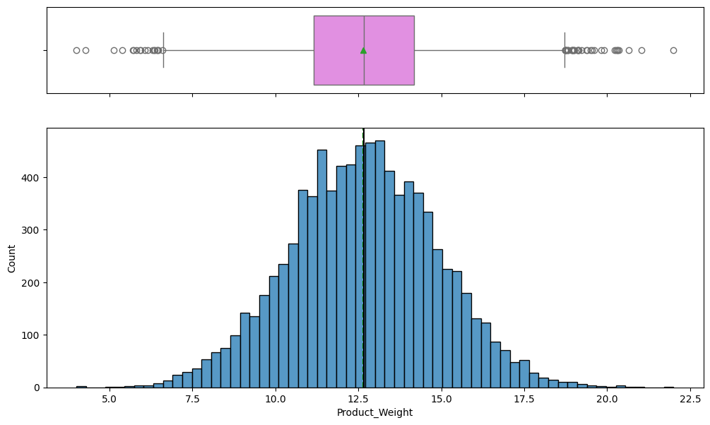

```python
histogram_boxplot(data, "Product_Weight")
```

**Observations:**

**Product_Allocated_Area**

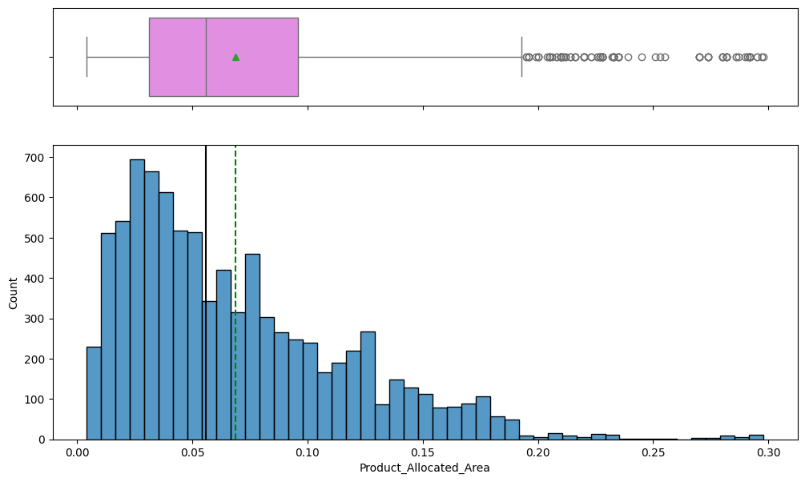

```python
histogram_boxplot(data, "Product_Allocated_Area")
```

**Observations:**

- Product_Allocated_Area is right skewed in distributed with a median of approximately 0.05

If we needed to perform a linear transformation:

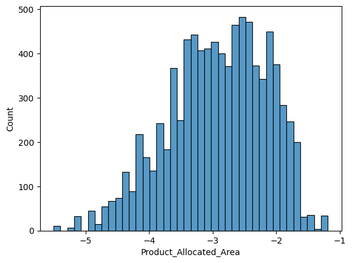

```python
sns.histplot(np.log(data['Product_Allocated_Area']) + .02)
```

.02 is a bias values added to tune

**Product_MRP**

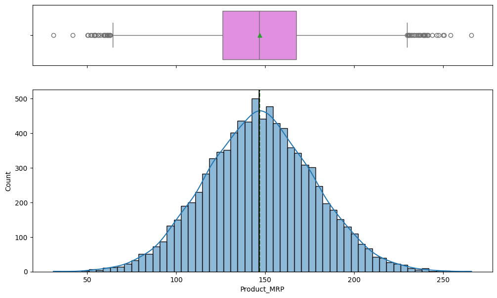

```python
histogram_boxplot(data, "Product_MRP", kde = True)
```

**Observations:**

**Product_Store_Sales_Total**

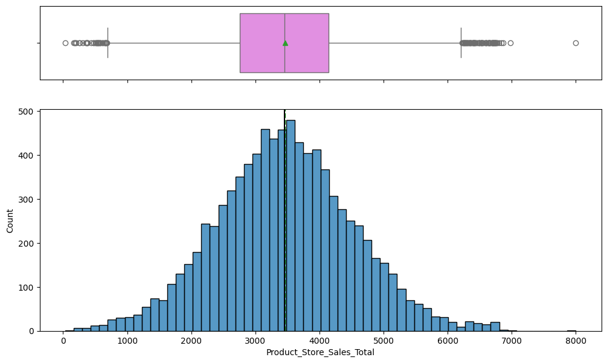

```python
histogram_boxplot(data, "Product_Store_Sales_Total")
```

**Observations:**

### **Data Distribtion for categorical features**

```python
# Function to create labeled barplots

def labeled_barplot(data, feature, perc = False, n = None):
    """
    Barplot with percentage at the top

    data: dataframe
    feature: dataframe column
    perc: whether to display percentages instead of count (default is False)
    n: displays the top n category levels (default is None, i.e., display all levels)
    """

    total = len(data[feature])            # Length of the column
    count = data[feature].nunique()
    if n is None:
        plt.figure(figsize = (count + 1, 5))
    else:
        plt.figure(figsize = (n + 1, 5))

    plt.xticks(rotation = 90, fontsize = 15)
    ax = sns.countplot(
        data = data,
        x = feature,
        palette = "Paired",
        order = data[feature].value_counts().index[:n].sort_values(),
    )

    for p in ax.patches:
        if perc == True:
            label = "{:.1f}%".format(
                100 * p.get_height() / total
            )                              # Percentage of each class of the category
        else:
            label = p.get_height()         # Count of each level of the category

        x = p.get_x() + p.get_width() / 2  # Width of the plot
        y = p.get_height()                 # Height of the plot

        ax.annotate(
            label,
            (x, y),
            ha = "center",
            va = "center",
            size = 12,
            xytext = (0, 5),
            textcoords = "offset points",
        )                                 # Annotate the percentage

    plt.show()                            # Show the plot
```

### **Product_Id**

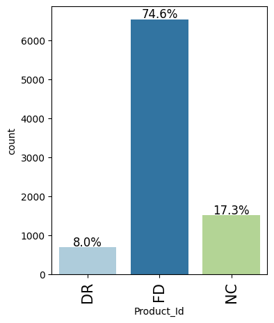

```python
labeled_barplot(data, "Product_Id", perc = True)
```

**Observations**

- Almost 75% of products sold fall under thye FD category (assumed to mean food)

### **Product_Sugar_Content**

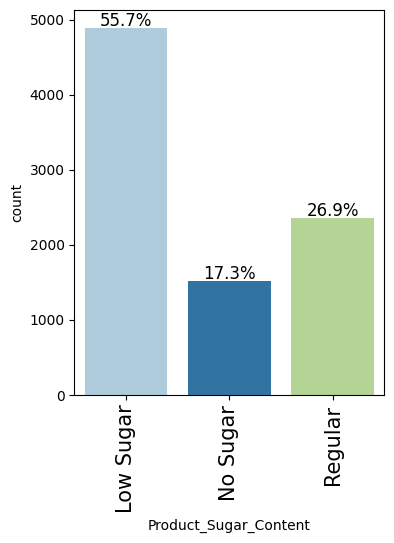

```python
labeled_barplot(data, "Product_Sugar_Content", perc = True)
```

**Observations:**

- Approximatley 56% of items are Low Sugar versus nearly 27% having regular sugar, with a little more that 17% having no sugar at all.

### **Product_Type**

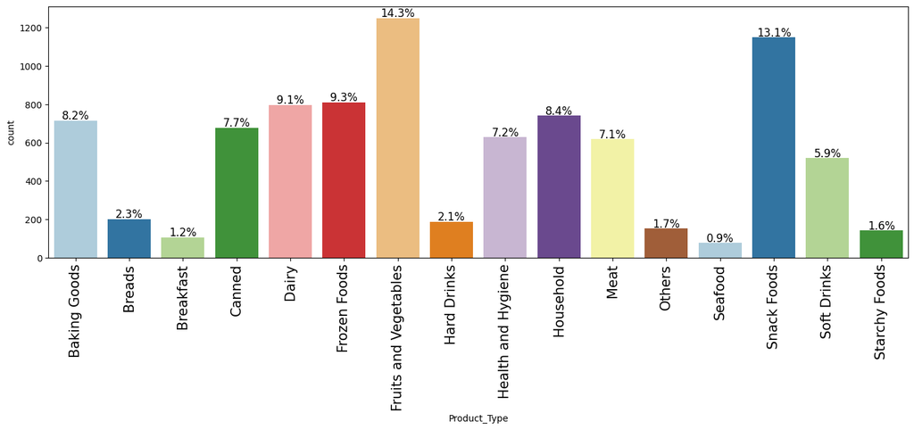

```python
labeled_barplot(data, "Product_Type", perc = True)
```

**Observations:**

### **Store_Id**

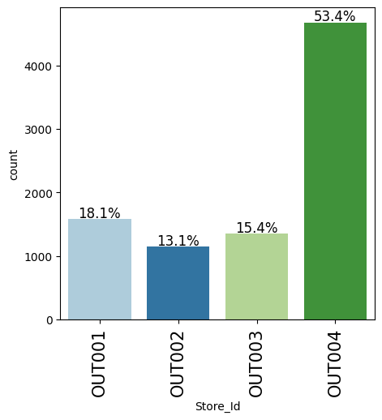

```python
labeled_barplot(data, "Store_Id", perc = True)
```

**Observations**

- OUT004 has the largest number of products at 53%, it is larger than all other stores combined.
- OUT002 has the lowest number of goods sold at just over 13%

### **Store_Size**

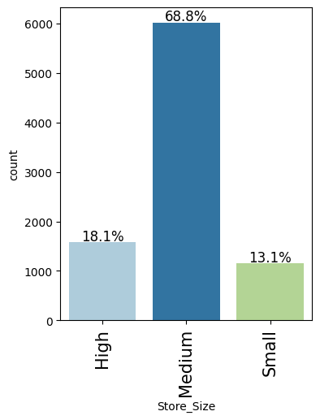

```python
labeled_barplot(data, "Store_Size", perc = True)
```

**Observations:**

- Medium stores account for almost 70% of all goods sold.
- High and Small stores account for roughly the same amout of sales.

### **Store_Location_City_Type**

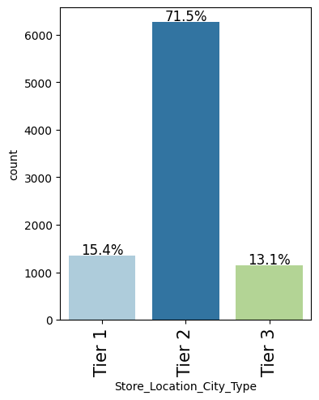

```python
labeled_barplot(data, "Store_Location_City_Type", perc = True)
```

**Observations:**

- Nearly 72% of the products have been sold from stores which are located in Tier 2 cities.
- The products that have been sold from the stores are located in Tier 1 and Tier 3 cities are almost the same.

### **Store_Type**

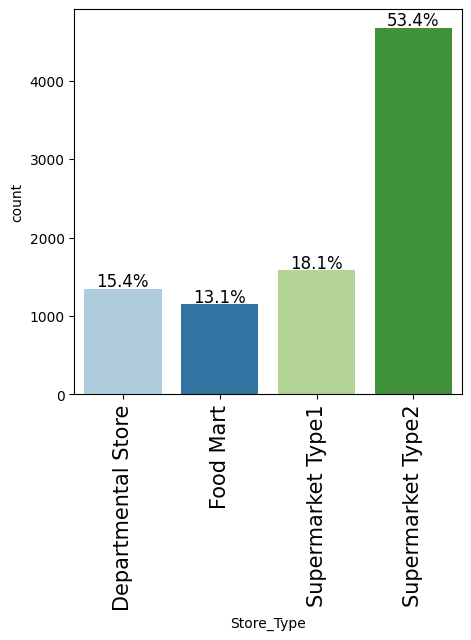

```python
labeled_barplot(data, "Store_Type", perc = True)
```

**Observations:**

- Supermarket Type2 stores account for over 53% of total sales.
- Department Sotres, Food Marts and SUpermarket Type 1 stores all have similar numbers of products sold.

# **Bivariate Analysis**

```python
# Create a copy of the dataset data dropping all non-numeric values

# Create a copy of the dataset
data_numeric = data.copy()

# Drop non-numeric columns
data_numeric = data_numeric.drop(['Product_Id', 'Product_Sugar_Content', 'Product_Type', 'Store_Id', 'Store_Size', 'Store_Location_City_Type', 'Store_Type'], axis=1)

# Display the first few rows of the new DataFrame
data_numeric.head()
```

|  | Product_Weight | Product_Allocated_Area | Product_MRP | Store_Establishment_Year | Product_Store_Sales_Total |
| --- | --- | --- | --- | --- | --- |
| 0 | 12.66 | 0.027 | 117.08 | 2009 | 2842.40 |
| 1 | 16.54 | 0.144 | 171.43 | 1999 | 4830.02 |
| 2 | 14.28 | 0.031 | 162.08 | 1987 | 4130.16 |
| 3 | 12.10 | 0.112 | 186.31 | 1987 | 4132.18 |
| 4 | 9.57 | 0.010 | 123.67 | 1998 | 2279.36 |

```python
# Create the correlation heatmap
data_numeric.corr()
```

|  | Product_Weight | Product_Allocated_Area | Product_MRP | Store_Establishment_Year | Product_Store_Sales_Total |
| --- | --- | --- | --- | --- | --- |
| Product_Weight | 1.000000 | 0.014754 | 0.532716 | -0.161907 | 0.737955 |
| Product_Allocated_Area | 0.014754 | 1.000000 | -0.009508 | 0.004467 | -0.000933 |
| Product_MRP | 0.532716 | -0.009508 | 1.000000 | -0.189357 | 0.787989 |
| Store_Establishment_Year | -0.161907 | 0.004467 | -0.189357 | 1.000000 | -0.185027 |
| Product_Store_Sales_Total | 0.737955 | -0.000933 | 0.787989 | -0.185027 | 1.000000 |

### **Correlation for Numerical Variables**

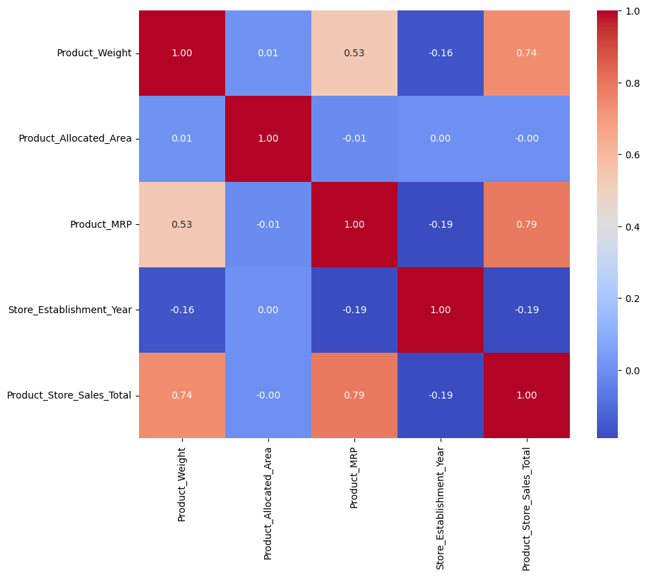

```python
# Plot the heatmap on data_numeric
plt.figure(figsize=(10, 8))
sns.heatmap(data_numeric.corr(), annot=True, fmt = '.2f', cmap='coolwarm')
# fmt is the precison (number of decimals)
plt.show()
```

**Observations:**

- Our target vaiable Product_Store_Sales_Total is highly correlated with Product_Weight and Product_MRP.
- Product_Weight and Product_MRP are moderatley correlated.
- Interestingly Store_Establishment_Year has a negative correlation with most other features.

### **Correlation for Categorical Variables**

```python
#data_rev = data.groupby(['Product_Id'], as_index = False)['Product_Store_Sales_Total'].sum()
#sns.barplot(x = 'Product_Id', y = 'Product_Store_Sales_Total', data = data_rev)
```

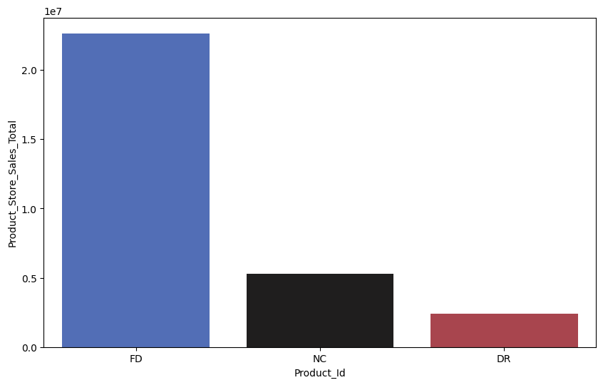

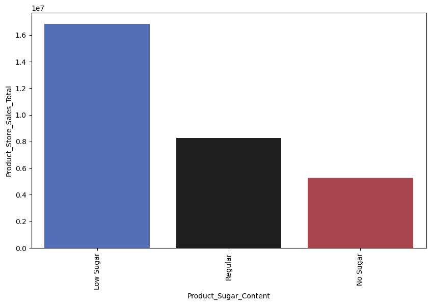

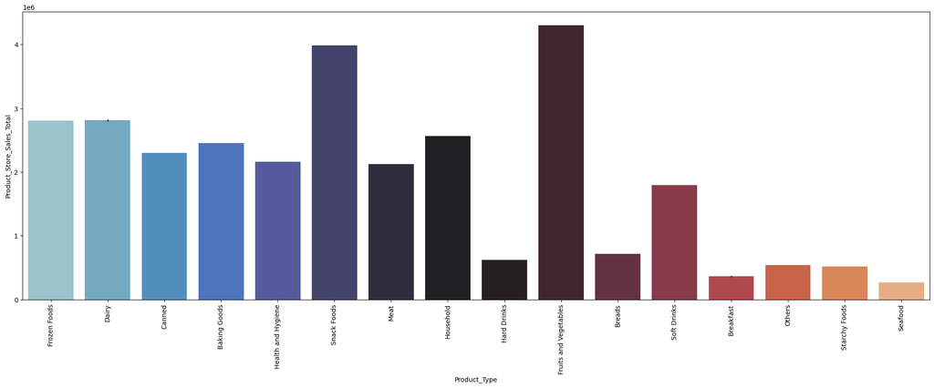

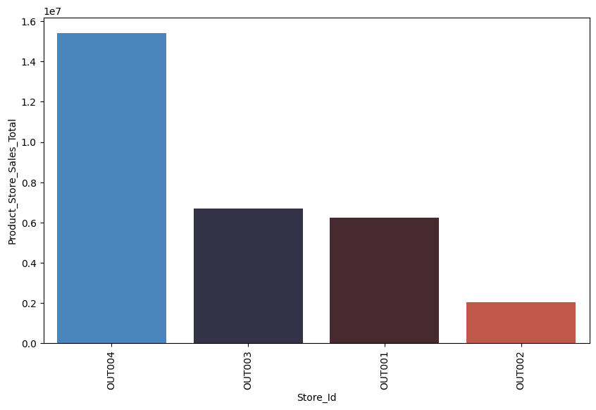

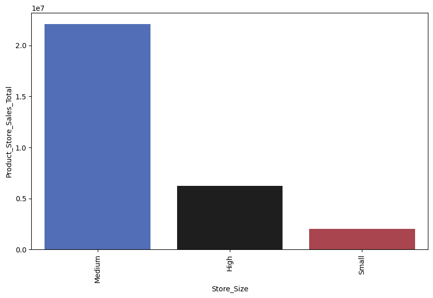

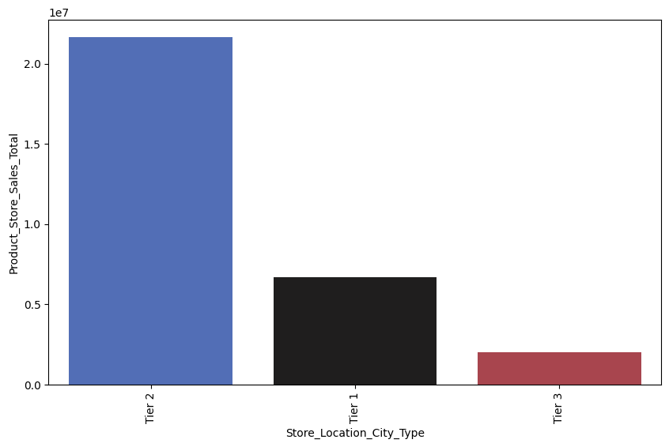

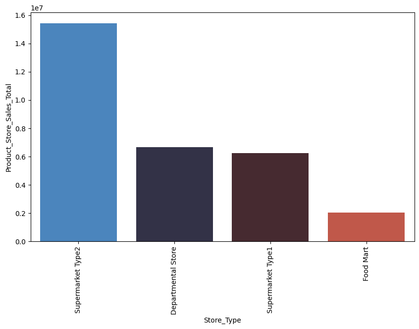

```python
# alternatley we could do the following:

# Visualize the effect of Product_Id on Product_Store_Sales_Total
plt.figure(figsize=(10, 6))
sns.barplot(data = data, x = 'Product_Id', y = 'Product_Store_Sales_Total', estimator = np.sum, ci = 1, palette = 'icefire')
plt.show()

## Removed as it did not give any insights
# Visualize the effect of Product_Weight on Product_Store_Sales_Total
#plt.figure(figsize=(25, 8))
#sns.barplot(data = data, x = 'Product_Weight', y = 'Product_Store_Sales_Total', estimator = np.sum, ci = 1, palette = 'icefire')
#plt.xticks(rotation = 90)
#plt.show()

# Visualize the effect of Product_Sugar_Content on Product_Store_Sales_Total
plt.figure(figsize=(10, 6))
sns.barplot(data = data, x = 'Product_Sugar_Content', y = 'Product_Store_Sales_Total', estimator = np.sum, ci = 1, palette = 'icefire')
plt.xticks(rotation = 90)
plt.show()

# Visualize the effect of Product_Type on Product_Store_Sales_Total
plt.figure(figsize=(25, 8))
sns.barplot(data = data, x = 'Product_Type', y = 'Product_Store_Sales_Total', estimator = np.sum, ci = 1, palette = 'icefire')
plt.xticks(rotation = 90)
plt.show()

# Visualize the effect of Store_Id on Product_Store_Sales_Total
plt.figure(figsize=(10, 6))
sns.barplot(data = data, x = 'Store_Id', y = 'Product_Store_Sales_Total', estimator = np.sum, ci = 1, palette = 'icefire')
plt.xticks(rotation = 90)
plt.show()

# Visualize the effect of Store_Size on Product_Store_Sales_Total
plt.figure(figsize=(10, 6))
sns.barplot(data = data, x = 'Store_Size', y = 'Product_Store_Sales_Total', estimator = np.sum, ci = 1, palette = 'icefire')
plt.xticks(rotation = 90)
plt.show()

# Visualize the effect of Store_Location_City_Type on Product_Store_Sales_Total
plt.figure(figsize=(10, 6))
sns.barplot(data = data, x = 'Store_Location_City_Type', y = 'Product_Store_Sales_Total', estimator = np.sum, ci = 1, palette = 'icefire')
plt.xticks(rotation = 90)
plt.show()

# Visualize the effect of Store_Type on Product_Store_Sales_Total
plt.figure(figsize=(10, 6))
sns.barplot(data = data, x = 'Store_Type', y = 'Product_Store_Sales_Total', estimator = np.sum, ci = 1, palette = 'icefire')
plt.xticks(rotation = 90)
plt.show()
```

### **Target Variable Distribution with Respect to Numerical Features**

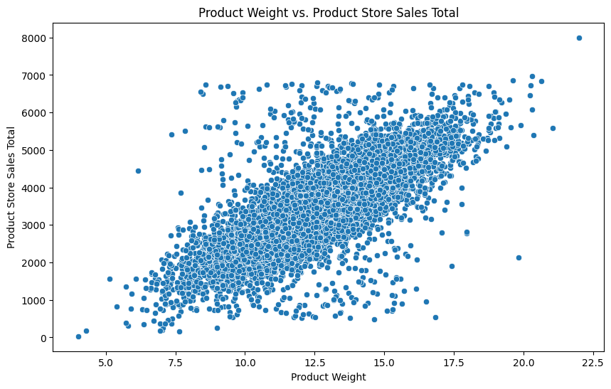

```python
# Visualize the relationship between Product_Weight and Product_Store_Sales_Total
plt.figure(figsize=(10, 6))
sns.scatterplot(x='Product_Weight', y='Product_Store_Sales_Total', data=data)
plt.title('Product Weight vs. Product Store Sales Total')
plt.xlabel('Product Weight')
plt.ylabel('Product Store Sales Total')
plt.show()
```

**Observations:**

- Product_Weight and Product_Store_Sales_Total are approximately linearly correlated.

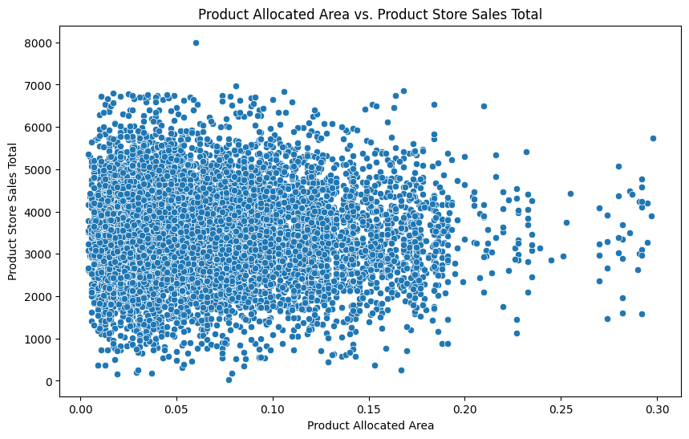

```python
# Visualize the relationship between Product_Allocated_Area and Product_Store_Sales_Total
plt.figure(figsize=(10, 6))
sns.scatterplot(x='Product_Allocated_Area', y='Product_Store_Sales_Total', data=data)
plt.title('Product Allocated Area vs. Product Store Sales Total')
plt.xlabel('Product Allocated Area')
plt.ylabel('Product Store Sales Total')
plt.show()
```

**Observations:**

- There does not appear to be a relationship between Product_Allocated_Area and Product_Store_Sales_Total.

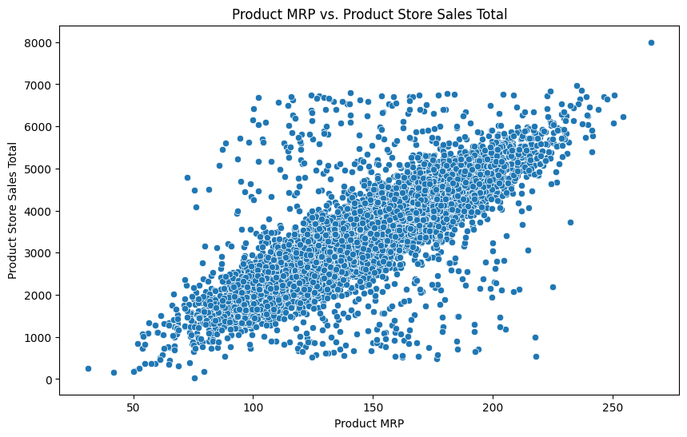

```python
# Visualize the relationship between Product_MRP and Product_Store_Sales_Total
plt.figure(figsize=(10, 6))
sns.scatterplot(x='Product_MRP', y='Product_Store_Sales_Total', data=data)
plt.title('Product MRP vs. Product Store Sales Total')
plt.xlabel('Product MRP')
plt.ylabel('Product Store Sales Total')
plt.show()
```

**Observations:**

- Product_MRP and Product_Store_Sales_Total are approximately linearly correlated.

```python
## Removed - not useful
# Visualize the relationship between Store_Establishment_Year and Product_Store_Sales_Total
#plt.figure(figsize=(10, 6))
#sns.scatterplot(x='Store_Establishment_Year', y='Product_Store_Sales_Total', data=data)
#plt.title('Store Establishment Year vs. Product Store Sales Total')
#plt.xlabel('Store Establishment Year')
#plt.ylabel('Product Store Sales Total')
#plt.show()
```

**Observations:**

### **Target Variable Distribution with Respect to Categorical Features**

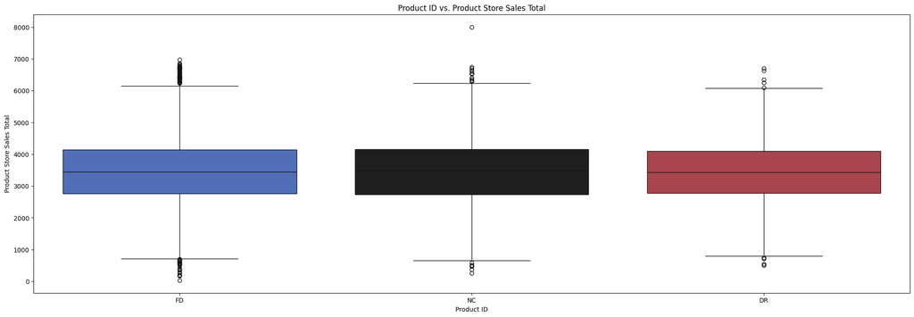

```python
# Visualize the relationship between Product_Id and Product_Store_Sales_Total
plt.figure(figsize=(25, 8))
sns.boxplot(x='Product_Id', y='Product_Store_Sales_Total', data=data, palette = 'icefire')
plt.title('Product ID vs. Product Store Sales Total')
plt.xlabel('Product ID')
plt.ylabel('Product Store Sales Total')
plt.show()
```

**Observations:**

- The difference are negligible between the Product_Id tyes.

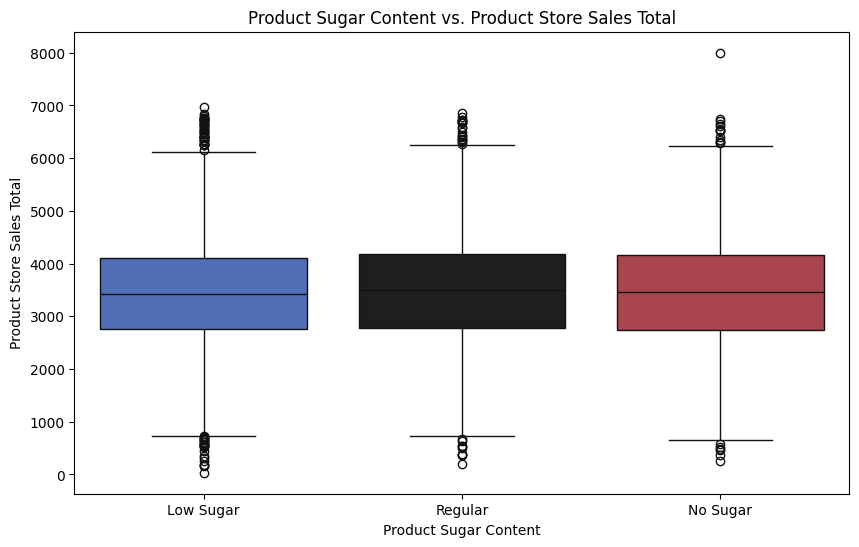

```python
# Visualize the relationship between Product_Sugar_Content and Product_Store_Sales_Total
plt.figure(figsize=(10, 6))
sns.boxplot(x='Product_Sugar_Content', y='Product_Store_Sales_Total', data=data, palette = 'icefire')
plt.title('Product Sugar Content vs. Product Store Sales Total')
plt.xlabel('Product Sugar Content')
plt.ylabel('Product Store Sales Total')
plt.show()
```

**Observations:**

- The effect of differences in SugarProduct_Sugar_Content in products appear to be negligible.

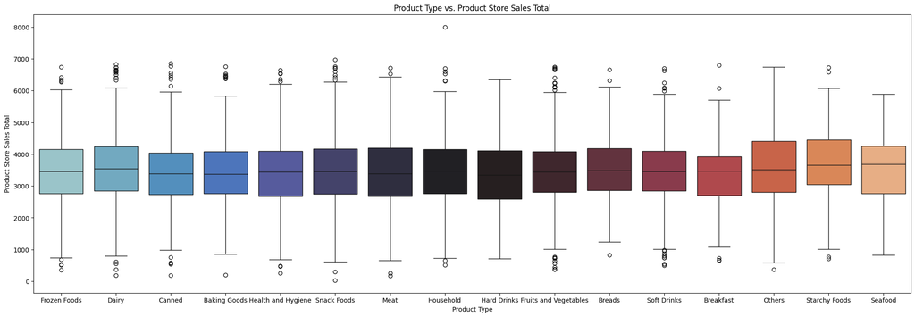

```python
# Visualize the relationship between Product_Type and Product_Store_Sales_Total
plt.figure(figsize=(25, 8))
sns.boxplot(x='Product_Type', y='Product_Store_Sales_Total', data=data, palette = 'icefire')
plt.title('Product Type vs. Product Store Sales Total')
plt.xlabel('Product Type')
plt.ylabel('Product Store Sales Total')
plt.show()
```

**Observations:**

- The effect of differences in Product_Type appears to be minimal.

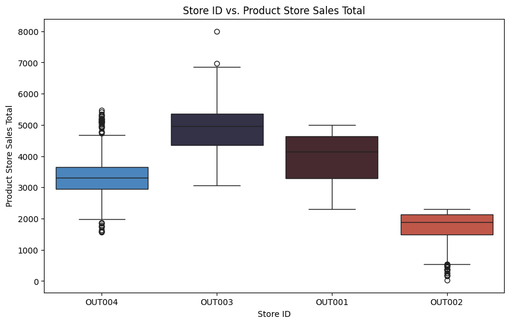

```python
# Visualize the relationship between Store_Id and Product_Store_Sales_Total
plt.figure(figsize=(10, 6))
sns.boxplot(x='Store_Id', y='Product_Store_Sales_Total', data=data, palette = 'icefire')
plt.title('Store ID vs. Product Store Sales Total')
plt.xlabel('Store ID')
plt.ylabel('Product Store Sales Total')
plt.show()
```

**Observations:**

- OUT003 has the highest median.
- OUT002 has sold the lowest median.

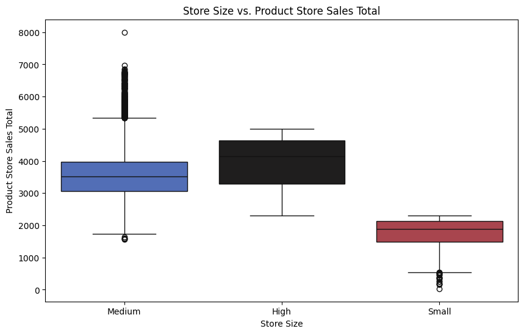

```python
# Visualize the relationship between Store_Size and Product_Store_Sales_Total
plt.figure(figsize=(10, 6))
sns.boxplot(x='Store_Size', y='Product_Store_Sales_Total', data=data, palette = 'icefire')
plt.title('Store Size vs. Product Store Sales Total')
plt.xlabel('Store Size')
plt.ylabel('Product Store Sales Total')
plt.show()
```

**Observations:**

- High sized stores appear to have the highest median.
- Small sized stores have the lowest median.

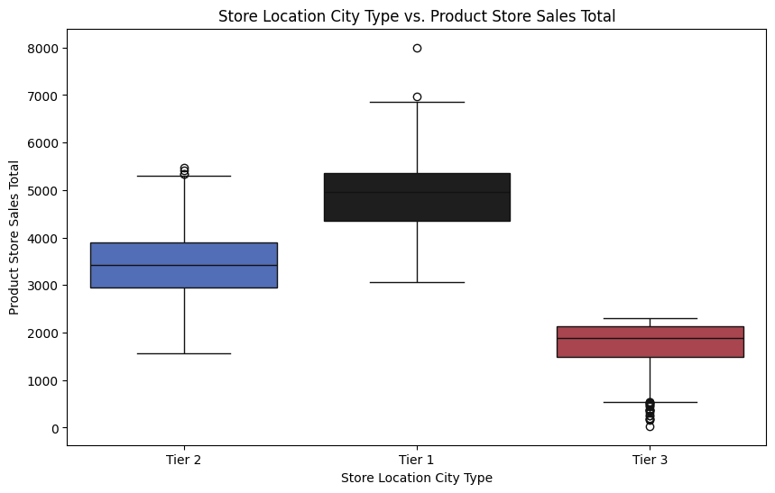

```python
# Visualize the relationship between Store_Location_City_Type and Product_Store_Sales_Total
plt.figure(figsize=(10, 6))
sns.boxplot(x='Store_Location_City_Type', y='Product_Store_Sales_Total', data=data, palette = 'icefire')
plt.title('Store Location City Type vs. Product Store Sales Total')
plt.xlabel('Store Location City Type')
plt.ylabel('Product Store Sales Total')
plt.show()
```

**Observations:**

- Stores in tier 1 cities have the highest median.
- Stores om tier 3 cities have the lowest median.

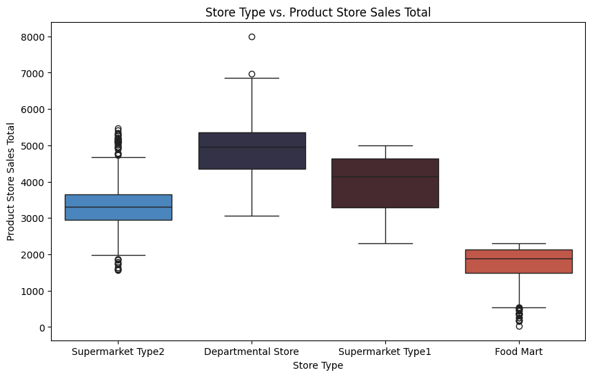

```python
# Visualize the relationship between Store_Type and Product_Store_Sales_Total
plt.figure(figsize=(10, 6))
sns.boxplot(x='Store_Type', y='Product_Store_Sales_Total', data=data, palette = 'icefire')
plt.title('Store Type vs. Product Store Sales Total')
plt.xlabel('Store Type')
plt.ylabel('Product Store Sales Total')
plt.show()
```

**Observations:**

- Department Stores have the highest median.
- Food Marts have the lowest median.